# Analysis of Foraging Penguin Size Data

Echefu Chinwendu

2024-02-13

# 1 Introduction

This data set contains size measurements for adult foraging penguins near Palmer Station, Antarctica. It includes measurements for penguin species, an island in Palmer Archipelago, size (flipper length, body mass, bill dimensions), and sex.

## 1.1 Objectives of this study

The following are the objectives that describe and explain the main purpose of this project.

1. To explore linear relationships within and across the species
2. For data visualization

## 1.2 Description of the Data

The dataset contains data for 344 penguins (rows) and 8 variables. There are 3 different species of penguins in this dataset, collected from 3 islands in the Palmer Archipelago, Antarctica. Variables in the data set include:

1. species - a factor denoting penguin species (Adélie, Chinstrap and Gentoo)
2. island - a factor denoting island in Palmer Archipelago, Antarctica (Biscoe, Dream or Torgersen)
3. bill_length_mm - a number denoting bill length (millimeters)
4. bill_depth_mm - a number denoting bill depth (millimeters)
5. flipper_length_mm - an integer denoting flipper length (millimeters)
6. body_mass_g - an integer denoting body mass (grams)
7. sex - a factor denoting penguin sex (female, male)
8. year - an integer denoting the study year (2007, 2008, or 2009)

A copy of this publicly available data is stored at https://github.com/chinwex/STA553/raw/main/w03-penguins.csv

# 2 Penguin data

The data contains 8 variables. 3 categorical variables and 5 numerical variables.The three categorical variables include Species, Island and Sex. The five numerical variables are: bill_length_mm, bill_depth_mm, flipper_length_mm, body_mass_g and year.

## 2.1 Missing Data

There are 19 missing values in this dataset.

## 2.2 Data

|  | species | island | bill_length_mm | bill_depth_mm | flipper_length_mm | body_mass_g | sex | year |
| --- | --- | --- | --- | --- | --- | --- | --- | --- |
| 1 | Adelie | Torgersen | 39.1 | 18.7 | 181 | 3750 | male | 2007 |
| 2 | Adelie | Torgersen | 39.5 | 17.4 | 186 | 3800 | female | 2007 |
| 3 | Adelie | Torgersen | 40.3 | 18 | 195 | 3250 | female | 2007 |
| 4 | Adelie | Torgersen |  |  |  |  |  | 2007 |
| 5 | Adelie | Torgersen | 36.7 | 19.3 | 193 | 3450 | female | 2007 |
| 6 | Adelie | Torgersen | 39.3 | 20.6 | 190 | 3650 | male | 2007 |
| 7 | Adelie | Torgersen | 38.9 | 17.8 | 181 | 3625 | female | 2007 |
| 8 | Adelie | Torgersen | 39.2 | 19.6 | 195 | 4675 | male | 2007 |
| 9 | Adelie | Torgersen | 34.1 | 18.1 | 193 | 3475 |  | 2007 |
| 10 | Adelie | Torgersen | 42 | 20.2 | 190 | 4250 |  | 2007 |

[output cut: 334 more lines]

The three species of penguins are Adelie(152 observations), Chinstrap(68 observations) and Gentoo(124 observations).

# 3 Plot

## 3.1 Plot of Bill Length vs Flipper Length

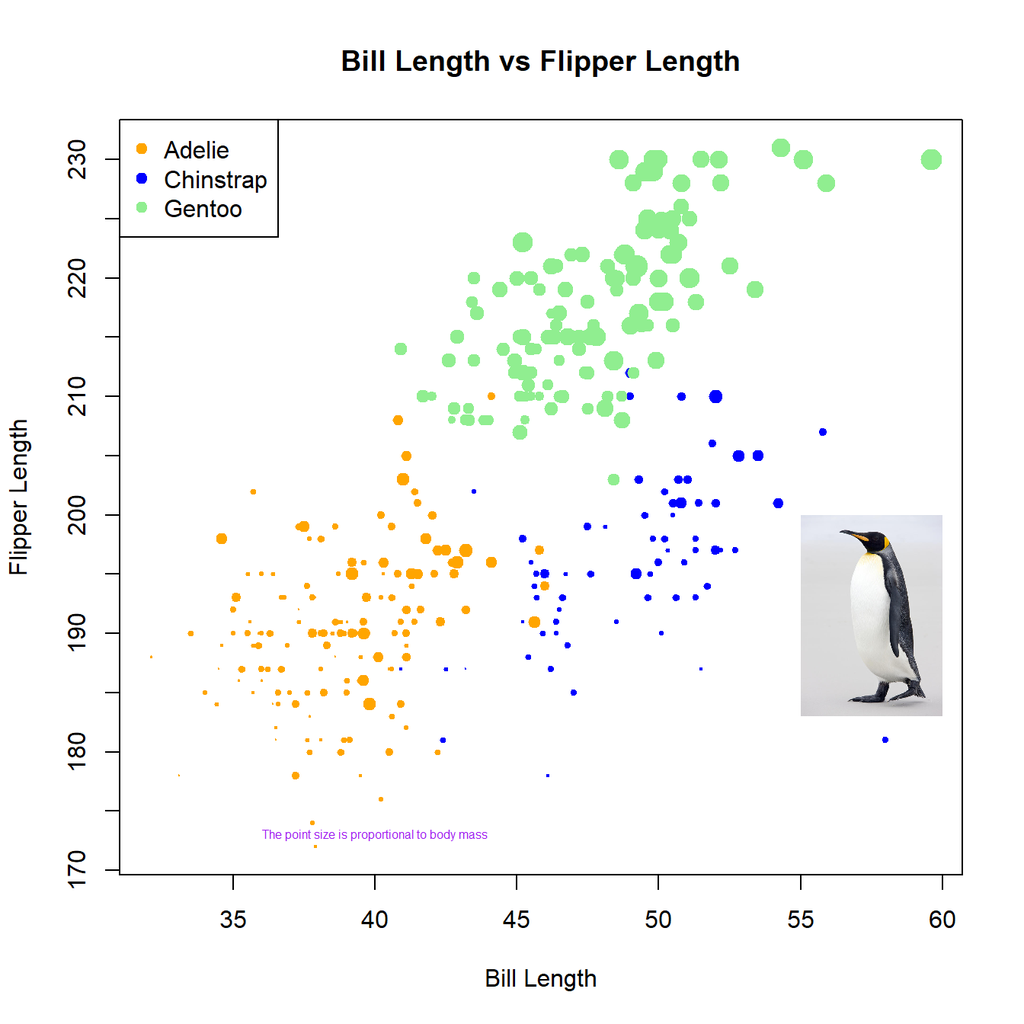

Scatter Plot Showing Bill Length and Flipper Length

## 3.2 Plot Interpretation

This is a scatterplot of bill length and flipper length of Palmer penguins. From the plot above, there are 3 different species of Palmer penguins - Adelie (orange dots), Chinstrap(blue dots), and Gentoo species(light green dots). The point sizes are proportional to the body mass of the corresponding penguin. There appears to be a positive correlation between the bill length of all 3 species of penguins and their flipper length. As the bill length increases, the flipper length also increases.

The Gentoo species have the highest flipper length and largest body mass when compared to the other two species while the Adelie species have the smallest bill length and flipper length.

# 4 Conclusion

A scatterplot was used to show the relationship between the two continuous variables - bill length and flipper length. From the above plot, it can be concluded that there is a positive linear relationship between bill length and flipper length.